# Masked_Face_Recognition

**Face recognition** is the general task of identifying and verifying people from photographs of their face. But nowadays and with the high propagation of the **COVID-19**, this task become more and more difficult due to the **masks** weared by the people. In this project, we will discover how to develop a **face recognition system** using **FaceNet** and an SVM and KNN classifiers to identify **Masked-People** from photographs.

## **Import the reaquired libraries**

```python
from IPython.display import clear_output
import numpy as np
from numpy import expand_dims
from numpy import asarray

from PIL import Image

from sklearn.preprocessing import Normalizer
from sklearn.preprocessing import LabelEncoder
from sklearn.metrics import accuracy_score
from sklearn.metrics import f1_score
from sklearn.metrics import recall_score
from sklearn.metrics import precision_score
from sklearn.metrics import classification_report
from sklearn.metrics import confusion_matrix

from sklearn import svm
from sklearn.neighbors import KNeighborsClassifier

from matplotlib import pyplot
import matplotlib.pyplot as plt
from mtcnn.mtcnn import MTCNN
from os import listdir
```

```python
# example of loading the keras facenet model
from keras.models import load_model
```

## **DataSet**

[figure not shown]

The work is divided into three parts:

- Face Detection
- Face Embedding
- Face Classification

## **FACE DETECTION**

For this task we will use a **deep learning model: MTCNN.**

We have three functions:

- **extract_face**: to extract a face from a given picture
- **load_faces**: to load faces from a given folder
- **load_dataset**: to load the whole dataset

```python
# confirm mtcnn was installed correctly
import mtcnn
# print version
print(mtcnn.__version__)
```

```
0.1.0
```

```python
# extract a single face from a given photograph
def extract_face(filename, required_size=(160, 160)):
	# load image from file
	image = Image.open(filename)
	# convert to RGB, if needed
	image = image.convert('RGB')
	# convert to array
	pixels = asarray(image)
	# create the detector, using default weights
	detector = MTCNN()
	# detect faces in the image
	results = detector.detect_faces(pixels)
	# extract the bounding box from the first face
	x1, y1, width, height = results[0]['box']
	# bug fix
	x1, y1 = abs(x1), abs(y1)
	x2, y2 = x1 + width, y1 + height
	# extract the face
	face = pixels[y1:y2, x1:x2]
	# resize pixels to the model size
	image = Image.fromarray(face)
	image = image.resize(required_size)
	face_array = asarray(image)
	return face_array
```

```python
# load images and extract faces for all images in a directory
def load_faces(directory):
	faces = list()
	# enumerate files
	for filename in listdir(directory):
		# path
		path = directory + filename
		# get face
		face = extract_face(path)
		# store
		faces.append(face)
	return faces
```

```python
# load a dataset that contains one subdir for each class that in turn contains images
def load_dataset(directory):
	X, y = list(), list()
	# enumerate folders, on per class
	for subdir in listdir(directory):
		# path
		path = directory + subdir + '/'
		# skip any files that might be in the dir
		#if not isdir(path):
			#continue
		# load all faces in the subdirectory
		faces = load_faces(path)
		# create labels
		labels = [subdir for _ in range(len(faces))]
		# summarize progress
		print('>loaded %d examples for class: %s' % (len(faces), subdir))
		# store
		X.extend(faces)
		y.extend(labels)
	return asarray(X), asarray(y)
```

```python
# load train dataset
trainX, trainy = load_dataset('train/')
print(trainX.shape, trainy.shape)
clear_output()
```

```python
# load test dataset
testX, testy = load_dataset('val/')
print(testX.shape, testy.shape)
clear_output()
```

```python
# save arrays to one file in compressed format
np.savez_compressed('masked-faces-dataset.npz', trainX, trainy, testX, testy)
```

```python
# load the face dataset
data = np.load('masked-faces-dataset.npz')
trainX, trainy, testX, testy = data['arr_0'], data['arr_1'], data['arr_2'], data['arr_3']
print('Loaded: ', trainX.shape, trainy.shape, testX.shape, testy.shape)
```

```
Loaded:  (427, 160, 160, 3) (427,) (105, 160, 160, 3) (105,)
```

As mentionned in the output of the last cell: we have **427 pictures** for the **train** and **105** for the **test**.

## **Face Embeddings**

In this part, We will use **Face Net**:It is a system that, given a picture of a face, will extract high-quality features from the face and predict a 128 element vector representation these features, called a face embedding. These **face embeddings** will then used as the basis for training classifier systems on standard face recognition benchmark datasets

```python
# load the model
model = load_model('facenet_keras.h5')
```

```
WARNING:tensorflow:No training configuration found in the save file, so the model was *not* compiled. Compile it manually.
```

```python
# get the face embedding for one face
def get_embedding(model, face_pixels):
	# scale pixel values
	face_pixels = face_pixels.astype('float32')
	# standardize pixel values across channels (global)
	mean, std = face_pixels.mean(), face_pixels.std()
	face_pixels = (face_pixels - mean) / std
	# transform face into one sample
	samples = expand_dims(face_pixels, axis=0)
	# make prediction to get embedding
	yhat = model.predict(samples)
	return yhat[0]
```

```python
# convert each face in the train set to an embedding
newTrainX = list()
for face_pixels in trainX:
	embedding = get_embedding(model, face_pixels)
	newTrainX.append(embedding)
newTrainX = asarray(newTrainX)
print(newTrainX.shape)
```

```
(427, 128)
```

```python
# convert each face in the test set to an embedding
newTestX = list()
for face_pixels in testX:
	embedding = get_embedding(model, face_pixels)
	newTestX.append(embedding)
newTestX = asarray(newTestX)
print(newTestX.shape)
```

```
(105, 128)
```

```python
# save arrays to one file in compressed format
np.savez_compressed('masked-faces-embeddings.npz', newTrainX, trainy, newTestX, testy)
```

```python
# load dataset
data = np.load('masked-faces-embeddings.npz')
trainX, trainy, testX, testy = data['arr_0'], data['arr_1'], data['arr_2'], data['arr_3']
print('Dataset: train=%d, test=%d' % (trainX.shape[0], testX.shape[0]))
```

```
Dataset: train=427, test=105
```

```python
# normalize input vectors
in_encoder = Normalizer(norm='l2')
trainX = in_encoder.transform(trainX)
testX = in_encoder.transform(testX)
```

```python
# label encode targets
out_encoder = LabelEncoder()
out_encoder.fit(trainy)
trainy = out_encoder.transform(trainy)
testy = out_encoder.transform(testy)
```

## **Face Classification**

### *SVC*

```python
# fit model
model = svm.SVC(kernel='linear')
model.fit(trainX, trainy)
```

```
SVC(C=1.0, cache_size=200, class_weight=None, coef0=0.0,
    decision_function_shape='ovr', degree=3, gamma='auto_deprecated',
    kernel='linear', max_iter=-1, probability=False, random_state=None,
    shrinking=True, tol=0.001, verbose=False)
```

```python
# predict
yhat_train = model.predict(trainX)
yhat_test = model.predict(testX)
```

**Evaluation for the Train**

```python
print ('Accuracy_train:', accuracy_score(trainy, yhat_train))
print ('F1 score_train:', f1_score(trainy, yhat_train,average='weighted'))
print ('Recall_train:', recall_score(trainy, yhat_train,
                              average='weighted'))
print ('Precision_train:', precision_score(trainy, yhat_train,
                                    average='weighted'))
print ('\n clasification report_train:\n', classification_report(trainy, yhat_train))
print ('\n confussion matrix_train:\n',confusion_matrix(trainy, yhat_train))
```

```
Accuracy_train: 0.990632318501171
F1 score_train: 0.9906293866649055
Recall_train: 0.990632318501171
Precision_train: 0.9913785864100476

 clasification report_train:
               precision    recall  f1-score   support

           0       0.99      1.00      1.00       122
           1       1.00      1.00      1.00       125
           2       1.00      0.90      0.95        10
           3       1.00      0.89      0.94         9
           4       1.00      1.00      1.00        13
           5       0.90      1.00      0.95         9
           6       1.00      1.00      1.00         9
           7       1.00      0.93      0.97        15
           8       1.00      1.00      1.00        17
           9       1.00      1.00      1.00        21
          10       1.00      1.00      1.00        11
          11       1.00      1.00      1.00        15
          12       1.00      0.95      0.98        21
          13       0.89      1.00      0.94        17
          14       1.00      1.00      1.00        13

    accuracy                           0.99       427
   macro avg       0.99      0.98      0.98       427
weighted avg       0.99      0.99      0.99       427


 confussion matrix_train:
 [[122   0   0   0   0   0   0   0   0   0   0   0   0   0   0]
 [  0 125   0   0   0   0   0   0   0   0   0   0   0   0   0]
 [  0   0   9   0   0   0   0   0   0   0   0   0   0   1   0]
 [  1   0   0   8   0   0   0   0   0   0   0   0   0   0   0]
 [  0   0   0   0  13   0   0   0   0   0   0   0   0   0   0]
 [  0   0   0   0   0   9   0   0   0   0   0   0   0   0   0]
 [  0   0   0   0   0   0   9   0   0   0   0   0   0   0   0]
 [  0   0   0   0   0   0   0  14   0   0   0   0   0   1   0]
 [  0   0   0   0   0   0   0   0  17   0   0   0   0   0   0]
 [  0   0   0   0   0   0   0   0   0  21   0   0   0   0   0]
 [  0   0   0   0   0   0   0   0   0   0  11   0   0   0   0]
 [  0   0   0   0   0   0   0   0   0   0   0  15   0   0   0]
 [  0   0   0   0   0   1   0   0   0   0   0   0  20   0   0]
 [  0   0   0   0   0   0   0   0   0   0   0   0   0  17   0]
 [  0   0   0   0   0   0   0   0   0   0   0   0   0   0  13]]
```

**Evaluation for the Test**

```python
print ('Accuracy_test:', accuracy_score(testy, yhat_test))
print ('F1 score_test:', f1_score(testy, yhat_test,average='weighted'))
print ('Recall_test:', recall_score(testy, yhat_test,
                              average='weighted'))
print ('Precision_test:', precision_score(testy, yhat_test,
                                    average='weighted'))
print ('\n clasification report_test:\n', classification_report(testy, yhat_test))
print ('\n confussion matrix_test:\n',confusion_matrix(testy, yhat_test))
```

```
Accuracy_test: 0.8285714285714286
F1 score_test: 0.8185969586437797
Recall_test: 0.8285714285714286
Precision_test: 0.8651251526251525

 clasification report_test:
               precision    recall  f1-score   support

           0       0.77      1.00      0.87        10
           1       0.94      1.00      0.97        15
           2       1.00      1.00      1.00         5
           3       1.00      1.00      1.00         5
           4       0.83      1.00      0.91         5
           5       1.00      0.40      0.57         5
           6       1.00      1.00      1.00         5
           7       0.58      0.78      0.67         9
           8       0.83      1.00      0.91         5
           9       1.00      1.00      1.00         5
          10       1.00      0.44      0.62         9
          11       1.00      0.71      0.83         7
          12       1.00      1.00      1.00         5
          13       0.50      0.86      0.63         7
          14       0.75      0.38      0.50         8

    accuracy                           0.83       105
   macro avg       0.88      0.84      0.83       105
weighted avg       0.87      0.83      0.82       105


 confussion matrix_test:
 [[10  0  0  0  0  0  0  0  0  0  0  0  0  0  0]
 [ 0 15  0  0  0  0  0  0  0  0  0  0  0  0  0]
 [ 0  0  5  0  0  0  0  0  0  0  0  0  0  0  0]
 [ 0  0  0  5  0  0  0  0  0  0  0  0  0  0  0]
 [ 0  0  0  0  5  0  0  0  0  0  0  0  0  0  0]
 [ 2  0  0  0  0  2  0  0  0  0  0  0  0  1  0]
 [ 0  0  0  0  0  0  5  0  0  0  0  0  0  0  0]
 [ 0  0  0  0  0  0  0  7  1  0  0  0  0  0  1]
 [ 0  0  0  0  0  0  0  0  5  0  0  0  0  0  0]
 [ 0  0  0  0  0  0  0  0  0  5  0  0  0  0  0]
 [ 0  1  0  0  1  0  0  1  0  0  4  0  0  2  0]
 [ 0  0  0  0  0  0  0  1  0  0  0  5  0  1  0]
 [ 0  0  0  0  0  0  0  0  0  0  0  0  5  0  0]
 [ 1  0  0  0  0  0  0  0  0  0  0  0  0  6  0]
 [ 0  0  0  0  0  0  0  3  0  0  0  0  0  2  3]]
```

### *KNN*

```python
knn = KNeighborsClassifier(n_neighbors=1, metric='euclidean')
knn.fit(trainX, trainy)
```

```
KNeighborsClassifier(algorithm='auto', leaf_size=30, metric='euclidean',
                     metric_params=None, n_jobs=None, n_neighbors=1, p=2,
                     weights='uniform')
```

```python
from sklearn.metrics import accuracy_score
# predict
yhat_train1 = knn.predict(trainX)
yhat_test1 = knn.predict(testX)
```

**Evaluation for the Train**

```python
print ('Accuracy_train:', accuracy_score(trainy, yhat_train1))
print ('F1 score_train:', f1_score(trainy, yhat_train,average='weighted'))
print ('Recall_train:', recall_score(trainy, yhat_train1,
                              average='weighted'))
print ('Precision_train:', precision_score(trainy, yhat_train1,
                                    average='weighted'))
print ('\n clasification report_train:\n', classification_report(trainy, yhat_train1))
print ('\n confussion matrix_train:\n',confusion_matrix(trainy, yhat_train1))
```

```
Accuracy_train: 1.0
F1 score_train: 0.9906293866649055
Recall_train: 1.0
Precision_train: 1.0

 clasification report_train:
               precision    recall  f1-score   support

           0       1.00      1.00      1.00       122
           1       1.00      1.00      1.00       125
           2       1.00      1.00      1.00        10
           3       1.00      1.00      1.00         9
           4       1.00      1.00      1.00        13
           5       1.00      1.00      1.00         9
           6       1.00      1.00      1.00         9
           7       1.00      1.00      1.00        15
           8       1.00      1.00      1.00        17
           9       1.00      1.00      1.00        21
          10       1.00      1.00      1.00        11
          11       1.00      1.00      1.00        15
          12       1.00      1.00      1.00        21
          13       1.00      1.00      1.00        17
          14       1.00      1.00      1.00        13

    accuracy                           1.00       427
   macro avg       1.00      1.00      1.00       427
weighted avg       1.00      1.00      1.00       427


 confussion matrix_train:
 [[122   0   0   0   0   0   0   0   0   0   0   0   0   0   0]
 [  0 125   0   0   0   0   0   0   0   0   0   0   0   0   0]
 [  0   0  10   0   0   0   0   0   0   0   0   0   0   0   0]
 [  0   0   0   9   0   0   0   0   0   0   0   0   0   0   0]
 [  0   0   0   0  13   0   0   0   0   0   0   0   0   0   0]
 [  0   0   0   0   0   9   0   0   0   0   0   0   0   0   0]
 [  0   0   0   0   0   0   9   0   0   0   0   0   0   0   0]
 [  0   0   0   0   0   0   0  15   0   0   0   0   0   0   0]
 [  0   0   0   0   0   0   0   0  17   0   0   0   0   0   0]
 [  0   0   0   0   0   0   0   0   0  21   0   0   0   0   0]
 [  0   0   0   0   0   0   0   0   0   0  11   0   0   0   0]
 [  0   0   0   0   0   0   0   0   0   0   0  15   0   0   0]
 [  0   0   0   0   0   0   0   0   0   0   0   0  21   0   0]
 [  0   0   0   0   0   0   0   0   0   0   0   0   0  17   0]
 [  0   0   0   0   0   0   0   0   0   0   0   0   0   0  13]]
```

**Evaluation for the Test**

```python
print ('Accuracy_test:', accuracy_score(testy, yhat_test1))
print ('F1 score_test:', f1_score(testy, yhat_test1,average='weighted'))
print ('Recall_test:', recall_score(testy, yhat_test1,
                              average='weighted'))
print ('Precision_test:', precision_score(testy, yhat_test1,
                                    average='weighted'))
print ('\n clasification report_test:\n', classification_report(testy, yhat_test1))
print ('\n confussion matrix_test:\n',confusion_matrix(testy, yhat_test1))
```

```
Accuracy_test: 0.7904761904761904
F1 score_test: 0.7788577881745583
Recall_test: 0.7904761904761904
Precision_test: 0.8159020873306588

 clasification report_test:
               precision    recall  f1-score   support

           0       0.77      1.00      0.87        10
           1       1.00      1.00      1.00        15
           2       1.00      1.00      1.00         5
           3       0.56      1.00      0.71         5
           4       0.71      1.00      0.83         5
           5       1.00      0.40      0.57         5
           6       1.00      1.00      1.00         5
           7       0.38      0.56      0.45         9
           8       1.00      1.00      1.00         5
           9       1.00      1.00      1.00         5
          10       1.00      0.56      0.71         9
          11       0.86      0.86      0.86         7
          12       0.83      1.00      0.91         5
          13       1.00      0.57      0.73         7
          14       0.25      0.12      0.17         8

    accuracy                           0.79       105
   macro avg       0.82      0.80      0.79       105
weighted avg       0.82      0.79      0.78       105


 confussion matrix_test:
 [[10  0  0  0  0  0  0  0  0  0  0  0  0  0  0]
 [ 0 15  0  0  0  0  0  0  0  0  0  0  0  0  0]
 [ 0  0  5  0  0  0  0  0  0  0  0  0  0  0  0]
 [ 0  0  0  5  0  0  0  0  0  0  0  0  0  0  0]
 [ 0  0  0  0  5  0  0  0  0  0  0  0  0  0  0]
 [ 0  0  0  3  0  2  0  0  0  0  0  0  0  0  0]
 [ 0  0  0  0  0  0  5  0  0  0  0  0  0  0  0]
 [ 0  0  0  0  0  0  0  5  0  0  0  1  1  0  2]
 [ 0  0  0  0  0  0  0  0  5  0  0  0  0  0  0]
 [ 0  0  0  0  0  0  0  0  0  5  0  0  0  0  0]
 [ 0  0  0  0  1  0  0  2  0  0  5  0  0  0  1]
 [ 0  0  0  0  0  0  0  1  0  0  0  6  0  0  0]
 [ 0  0  0  0  0  0  0  0  0  0  0  0  5  0  0]
 [ 2  0  0  1  0  0  0  0  0  0  0  0  0  4  0]
 [ 1  0  0  0  1  0  0  5  0  0  0  0  0  0  1]]
```

Here is a summuary for both the **SVM** and **KNN** classifiers

**KNN**

[output not shown]

**SVM**

| Metrics | Train | Test |
| --- | --- | --- |
| Accuracy | 0.99 | 0.82 |
| F1 score | 0.99 | 0.81 |
| Recall | 0.99 | 0.82 |
| Precision | 0.99 | 0.86 |

```
Predicted: dida (61.588)
Expected: dida
```

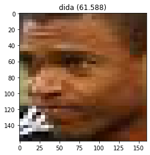

```python
# develop a classifier for the 5 Celebrity Faces Dataset
from random import choice
from numpy import load
from numpy import expand_dims
from sklearn.preprocessing import LabelEncoder
from sklearn.preprocessing import Normalizer
from sklearn.svm import SVC
from matplotlib import pyplot
# load faces
data = load('masked-faces-dataset.npz')
testX_faces = data['arr_2']
# load face embeddings
data = load('masked-faces-embeddings.npz')
trainX, trainy, testX, testy = data['arr_0'], data['arr_1'], data['arr_2'], data['arr_3']
# normalize input vectors
in_encoder = Normalizer(norm='l2')
trainX = in_encoder.transform(trainX)
testX = in_encoder.transform(testX)
# label encode targets
out_encoder = LabelEncoder()
out_encoder.fit(trainy)
trainy = out_encoder.transform(trainy)
testy = out_encoder.transform(testy)
# fit model
model = SVC(kernel='linear', probability=True)
model.fit(trainX, trainy)
# test model on a random example from the test dataset
selection = choice([i for i in range(testX.shape[0])])
random_face_pixels = testX_faces[selection]
random_face_emb = testX[selection]
random_face_class = testy[selection]
random_face_name = out_encoder.inverse_transform([random_face_class])
# prediction for the face
samples = expand_dims(random_face_emb, axis=0)
yhat_class = model.predict(samples)
yhat_prob = model.predict_proba(samples)
# get name
class_index = yhat_class[0]
class_probability = yhat_prob[0,class_index] * 100
predict_names = out_encoder.inverse_transform(yhat_class)
print('Predicted: %s (%.3f)' % (predict_names[0], class_probability))
print('Expected: %s' % random_face_name[0])
# plot for fun
pyplot.imshow(random_face_pixels)
title = '%s (%.3f)' % (predict_names[0], class_probability)
pyplot.title(title)
pyplot.show()
```